# DataAnalysis

Ana Palacio

June 7, 2018

## Import the data and organize factors

```r
# Load data from file
qPCR.data <- read.csv("data/qPCR_data.csv")


# Organize factors

  # Time points
    qPCR.data$Time <- factor (as.factor(qPCR.data$Time), levels=c("T0","T1","T2","T3","T4", "T5",
                                                                  "T8", "T9", "T10",
                                                                  "T11", "T12", "T13","T14",
                                                                  "T15","T16", "T17",
                                                                  "T20", "T23", "T24",
                                                                  "T26"))
  # Colony by mean D dominance
    qPCR.data$Colony<-factor(as.character(qPCR.data$Colony),
                             levels=c("S1","S4","S3","S5","S6","S2"))

  # Get the dates in the date format and extract the number of days in the experiment
    qPCR.data$Date <- (as.Date(qPCR.data$Date, format="%Y-%m-%d"))
    qPCR.data$Days <- (as.numeric(qPCR.data$Date)-16616)
```

## Exploratory graphs

### D proportions

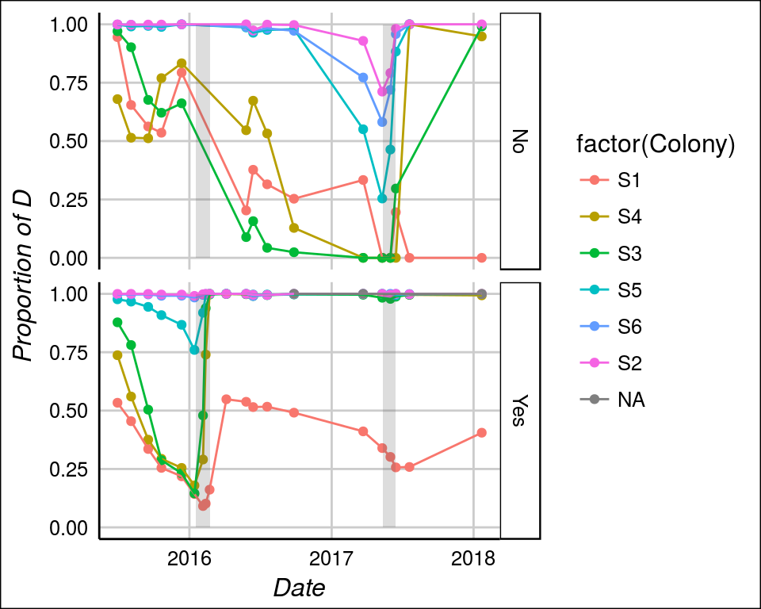

```r
# library(ggplot2)
# library(ggthemes)


# 1. Mean proportion of clade D symbiodinium over time by colony and beached vs not bleached in 2016

Dprop_all <- ggplot(qPCR.data, aes (Date, D.Prp, colour=factor(Colony))) +
  stat_summary(fun.data = "mean_cl_boot",geom = "point")+
    # stat_summary(fun.y = "median", geom = "point") +
    # stat_summary(fun.data = "mean_cl_boot",geom = "errorbar")+
   stat_summary(fun.data = "mean_cl_boot",geom = "line")+
    ylab("Proportion of D") +
    xlab("Date")  +  theme_gdocs( )  +
    facet_grid(Bleached_1~.)
Dprop_all +
    annotate("rect", xmin= as.Date("2016-01-18"), xmax = as.Date("2016-02-23"),
             ymin = 0, ymax = 1, alpha = .2) +
    annotate("rect", xmin= as.Date("2017-05-12"),
             xmax = as.Date("2017-06-15"), ymin = 0, ymax = 1, alpha = .2)
```

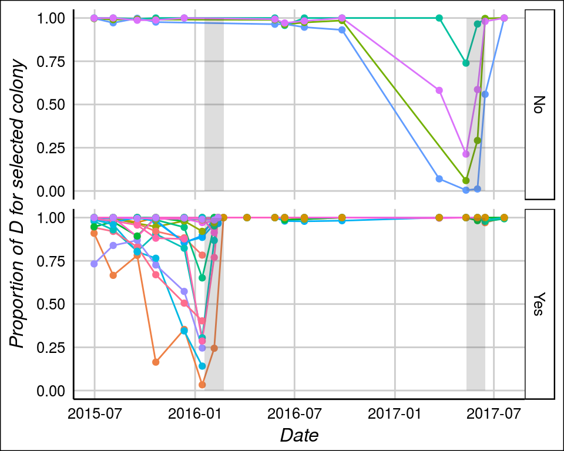

```r
  # Notes: Colonies with initially more C, transition faster to C dominated colonies. Is this a colony effect or just a result of having more C to start with?. Check individual core trajectories in each colony??


# 2. Proportion of clade D symbiodinium over time in each core and divided between beached vs not bleached in 2016

## Change the subset options from S1 to S6 to look at the different colonies

Dprop_Selected_colony <- ggplot(subset(qPCR.data, Colony=="S5"), aes (Date, D.Prp, colour=factor(Core))) +
   geom_line() +
   geom_point() +
    ylab("Proportion of D for selected colony") +
    xlab("Date")  +  theme_gdocs( )  +
    facet_grid(Bleached_1~.) + theme(legend.position="none")

Dprop_Selected_colony +
    annotate("rect", xmin= as.Date("2016-01-18"), xmax = as.Date("2016-02-23"),
             ymin = 0, ymax = 1, alpha = .2) +
    annotate("rect", xmin= as.Date("2017-05-12"),
             xmax = as.Date("2017-06-15"), ymin = 0, ymax = 1, alpha = .2)
```

```r
# Notes: Does not seem to be a Colony effect, but a Initial D proportion effect. Also, cores with non-detectable C that were not bleached in 2016 gained considerable amounts of C by mid 2017 (Colonies S2, S5, S6)!
```

What is driving the changes in D proportion? Is C increasing under control temperature? D decreasing? both?

### Symbiont to host cell ratio (S/H, C/H, D/H)

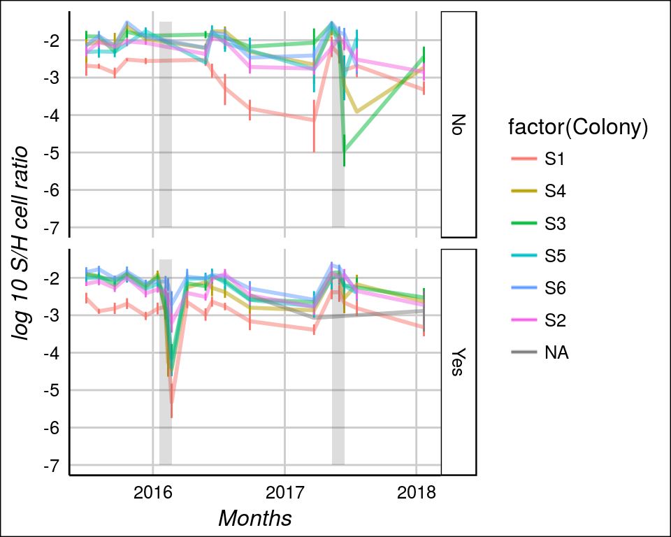

```r
# 1. Average total symbiont to host cell ratio over time per colony and Bleached vs not bleached in 2016

  SH_all <- ggplot(qPCR.data, aes (Date, log10(Tot.SH), colour=factor(Colony))) +
      stat_summary(fun.data = "mean_cl_boot",geom = "errorbar", width = 0.2)+
      stat_summary(fun.y=mean, geom="line", size =1, alpha=0.5) + ylim(-7,-1.5) +
      ylab("log 10 S/H cell ratio") +
      xlab("Months")  +  theme_gdocs( )  +
      #scale_x_continuous(breaks = seq(0, 40, by = 3)) +
      facet_grid(Bleached_1~.) # Where the corals bleached in 2016?
  SH_all +  # Bleaching periods in gray
      annotate("rect", xmin= as.Date("2016-01-18"),
               xmax = as.Date("2016-02-23"), ymin = -7, ymax = -1.5, alpha = .2) +
       annotate("rect", xmin= as.Date("2017-05-12"),
             xmax = as.Date("2017-06-15"), ymin = -7, ymax = -2, alpha = .2)
```

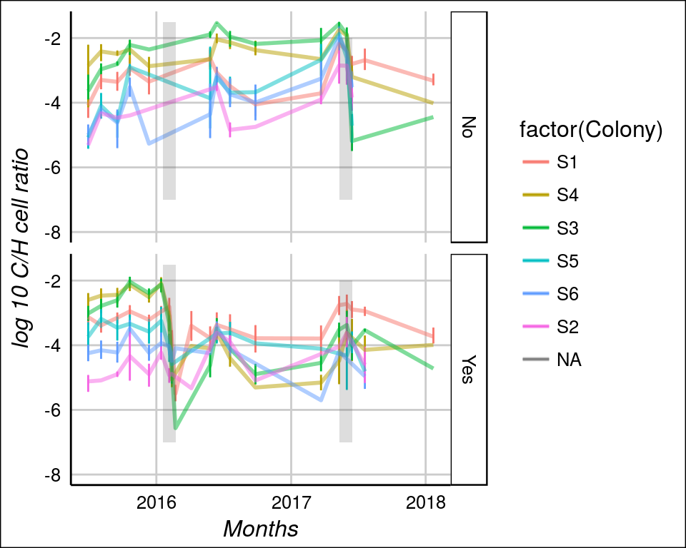

```r
    # Notes: Colony S1 decline in corals not bleached is weird. Test other symbionts different that C and D??
  # Stronger reduction on the S/H cell ratio in the first bleaching event (2016)


# 2. Average C symbiont to host cell ratio over time per colony and Bleached vs not bleached in 2016
  SC_all <- ggplot(qPCR.data, aes (Date, log10(C.SH), colour=factor(Colony))) +
      stat_summary(fun.data = "mean_cl_boot",geom = "errorbar", width = 0.2)+
      stat_summary(fun.y=mean, geom="line", size =1, alpha=0.5) + ylim(-8,-1.5) +
      ylab("log 10 C/H cell ratio") +
    xlab("Months")  +  theme_gdocs( )  +
    # scale_x_continuous(breaks = seq(0, 40, by = 3)) +
      facet_grid(Bleached_1~.) # Where the corals bleached in 2016?
  SC_all + # Bleaching periods in gray
      annotate("rect", xmin= as.Date("2016-01-18"),
               xmax = as.Date("2016-02-23"), ymin = -7, ymax = -1.5, alpha = .2) +
      annotate("rect", xmin= as.Date("2017-05-12"),
               xmax = as.Date("2017-06-15"), ymin = -7, ymax = -2, alpha = .2)
```

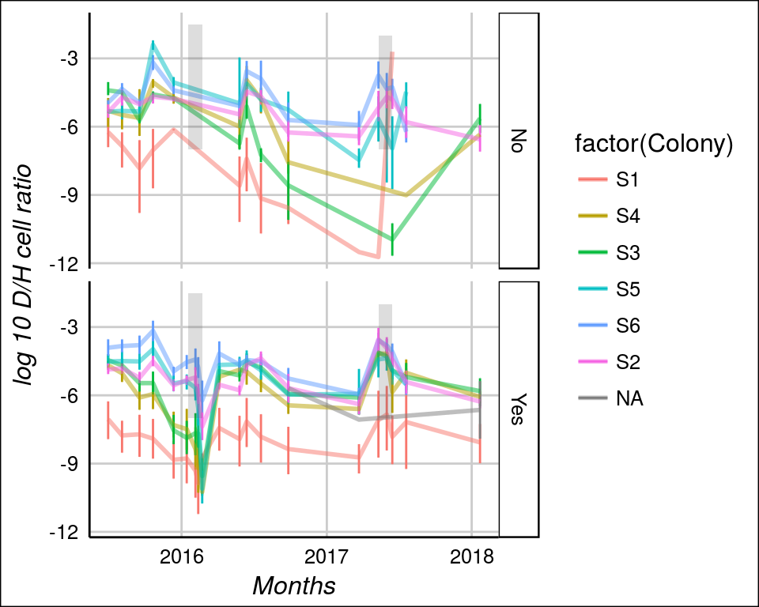

```r
  # Notes: Use "No" bleached data to calculate the population growth on symbiodinium C when there is not heat stress??

# 3. Average D symbiont to host cell ratio over time per colony and Bleached vs not bleached in 2016
DC_all <- ggplot(qPCR.data, aes (Date, log(D.SH), colour=factor(Colony))) +
    stat_summary(fun.data = "mean_cl_boot",geom = "errorbar", width = 0.2)+
    stat_summary(fun.y=mean, geom="line", size =1, alpha=0.5) +# ylim(-7,-1.5) +
    ylab("log 10 D/H cell ratio") +
  xlab("Months")  +  theme_gdocs( )  +
  # scale_x_continuous(breaks = seq(0, 40, by = 3)) +
  facet_grid(Bleached_1~.) # Where the corals bleached in 2016?

DC_all + # Bleaching periods in gray
    annotate("rect", xmin= as.Date("2016-01-18"),
             xmax = as.Date("2016-02-23"), ymin = -7, ymax = -1.5, alpha = .2) +
    annotate("rect", xmin= as.Date("2017-05-12"),
             xmax = as.Date("2017-06-15"), ymin = -7, ymax = -2, alpha = .2)
```

Lots of noise, but C seems to increase as well D to decrease when there is not temperature stress.

- Figure what is the best model(s) to address this
- Remove T3 data points with weird D peak?
- Try Lotka-Volterra competition coefficients. Ideas:
- Coral host cells as limiting resource (space, access to light)?
- Time = days under a specific temperature
- Specific growth rates and competition coefficients are unknown (Question: how temperature influence specific growth rates?)
- C better competitor in low temperatures
- D better competitor under heat stress (bleaching) temperature
- What about high, but not bleaching temperatures? (~29C)
- C and D do not seem to coexist under stable conditions, mixed C/D communities are unstable and seems to be in transition to one of the C or D dominated states.
- Try quasi-binomial models to estimate D proportion over time under control temperatures.

## Quasi-binomial models for D proportion

### 1. Model before the first bleaching event

Cores that were bleached in 2016 were maintained in more constant conditions (Temperature and light) than the ones that were not bleached.

- Used this data to describe the changes in D proportion under temperature ~26-27C (Bleached==“Yes”).
- Remove the corals that were shaded (Tre_1 != “Dark”)

```r
BeforeBleaching1<-subset(qPCR.data, Days<200) # Remove data points after bleaching
BeforeBleaching1<-subset(BeforeBleaching1, Bleached_1=="Yes")
BeforeBleaching1<-subset(BeforeBleaching1, Tre_1 != "Dark")

# Add Initial D proportion in each core (during T= T0) as a variable
for (Core in BeforeBleaching1$Core) {
  tdata <- BeforeBleaching1[which(BeforeBleaching1$Core==Core), ]
  for (Days in BeforeBleaching1$Days) {
    tdata[which(tdata$Days==Days), "Initial_D"] <- tdata[which(tdata$Days==0), "D.Prp"]
  }
  BeforeBleaching1[which(BeforeBleaching1$Core==Core), "Initial_D"] <- tdata[, "Initial_D"]
}
```

Rank the cores by Initial_D_Proportion.

This variable is what I will evaluate as a predictor of D proportion over time. Why? * there are very few C dominated cores at the begining of the experiment and a lot of D dominated cores. * Dividing the cores by initial D proportion ranks: - I lost detail of what happen with <50% D cores (not interesting… all stay C dominated, rapidly become 100% C) - Keep details of what happen within >80% D cores (super interesting… small differences in the initial proportion determine how fast the cores gain more C)

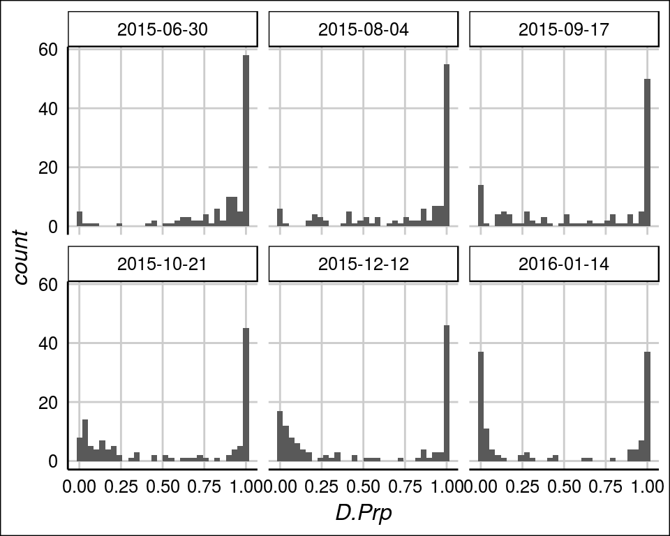

```r
# D proportion histograms
  Dprop_Hist <- ggplot(BeforeBleaching1, aes (D.Prp)) +
    geom_histogram() + facet_wrap(~Date) +  theme_gdocs( )
  Dprop_Hist
```

```r
  # Note: very few data points <50% D at time T=T0 (2015-06-30)

# Initial D_segments

BeforeBleaching1$D.PrpRank_Ini<-rank(BeforeBleaching1$Initial_D)
BeforeBleaching1$D.PrpRank_Ini<-cut(BeforeBleaching1$D.PrpRank_Ini,
                                      seq(9,760,100), include.lowest=TRUE)
```

Define and test the model

- I tried Colony and Treatment (Tre_1) as factors, but only one treatment is different. Colony was significant but split them between D dominated and C dominated colonies, so I thinks this is an artifact of the number of cores with high or low D proportion in each colony.

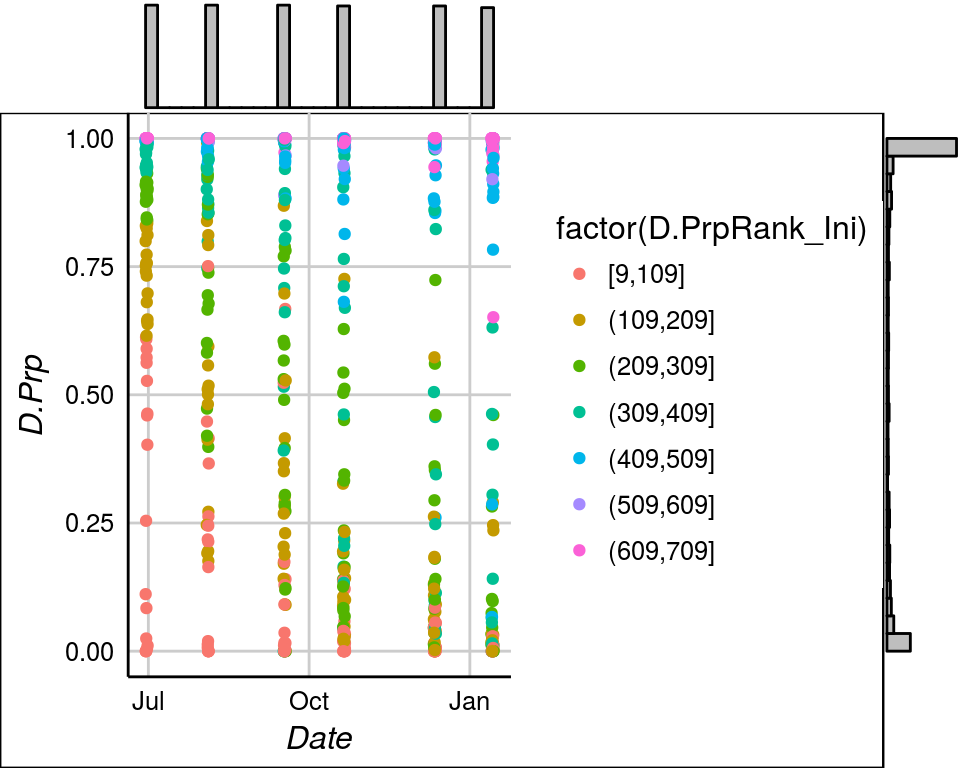

```r
Dprop_BeforeB <- ggplot(BeforeBleaching1, aes (Date, D.Prp, colour=factor(D.PrpRank_Ini))) +
    geom_jitter(width = 0.6) +  theme_gdocs( )
ggExtra::ggMarginal(Dprop_BeforeB, type = 'histogram', margins = 'both',
                    size = 5,  colour = 'black',  fill = 'gray')
```

```r
Dprop_BeforeB <- ggplot(BeforeBleaching1, aes (Date, D.Prp, colour=factor(D.PrpRank_Ini))) +
  stat_smooth(method="glm", family="binomial")



# Initial Proportion Model by rank

  D.Prp_Rank<-glm (D.Prp ~ Days + D.PrpRank_Ini, family = quasibinomial,
                 data=BeforeBleaching1,  na.action=na.omit)

    summary(D.Prp_Rank)
```

```
##
## Call:
## glm(formula = D.Prp ~ Days + D.PrpRank_Ini, family = quasibinomial,
##     data = BeforeBleaching1, na.action = na.omit)
##
## Deviance Residuals:
##      Min        1Q    Median        3Q       Max
## -1.74799  -0.15105   0.03522   0.16453   1.78087
##
## Coefficients:
##                          Estimate Std. Error t value Pr(>|t|)
## (Intercept)            -0.7149157  0.1450769  -4.928 1.03e-06 ***
## Days                   -0.0189534  0.0009555 -19.836  < 2e-16 ***
## D.PrpRank_Ini(109,209]  1.4861354  0.1775881   8.368 3.03e-16 ***
## D.PrpRank_Ini(209,309]  2.1875399  0.1782198  12.274  < 2e-16 ***
## D.PrpRank_Ini(309,409]  3.4953224  0.1912321  18.278  < 2e-16 ***
## D.PrpRank_Ini(409,509]  6.0863360  0.2699833  22.543  < 2e-16 ***
## D.PrpRank_Ini(509,609]  7.8100612  0.7603635  10.271  < 2e-16 ***
## D.PrpRank_Ini(609,709]  8.7633589  0.5266146  16.641  < 2e-16 ***
## ---
## Signif. codes:  0 '***' 0.001 '**' 0.01 '*' 0.05 '.' 0.1 ' ' 1
##
## (Dispersion parameter for quasibinomial family taken to be 0.1924671)
##
##     Null deviance: 654.49  on 726  degrees of freedom
## Residual deviance: 126.64  on 719  degrees of freedom
## AIC: NA
##
## Number of Fisher Scoring iterations: 8
```

```r
    confint(D.Prp_Rank)
```

```
##                              2.5 %      97.5 %
## (Intercept)            -1.00572094 -0.43610866
## Days                   -0.02086133 -0.01711394
## D.PrpRank_Ini(109,209]  1.14229047  1.83908226
## D.PrpRank_Ini(209,309]  1.84351273  2.54268791
## D.PrpRank_Ini(309,409]  3.12756482  3.87762633
## D.PrpRank_Ini(409,509]  5.57277627  6.63259235
## D.PrpRank_Ini(509,609]  6.56795273  9.71628439
## D.PrpRank_Ini(609,709]  7.84615553  9.96055092
```

```r
    MASS::dropterm(D.Prp_Rank, test="F")  # Partial F-tests
```

```
## Single term deletions
##
## Model:
## D.Prp ~ Days + D.PrpRank_Ini
##               Df Deviance F value     Pr(F)
## <none>             126.64
## Days           1   232.12  598.80 < 2.2e-16 ***
## D.PrpRank_Ini  6   604.67  452.32 < 2.2e-16 ***
## ---
## Signif. codes:  0 '***' 0.001 '**' 0.01 '*' 0.05 '.' 0.1 ' ' 1
```

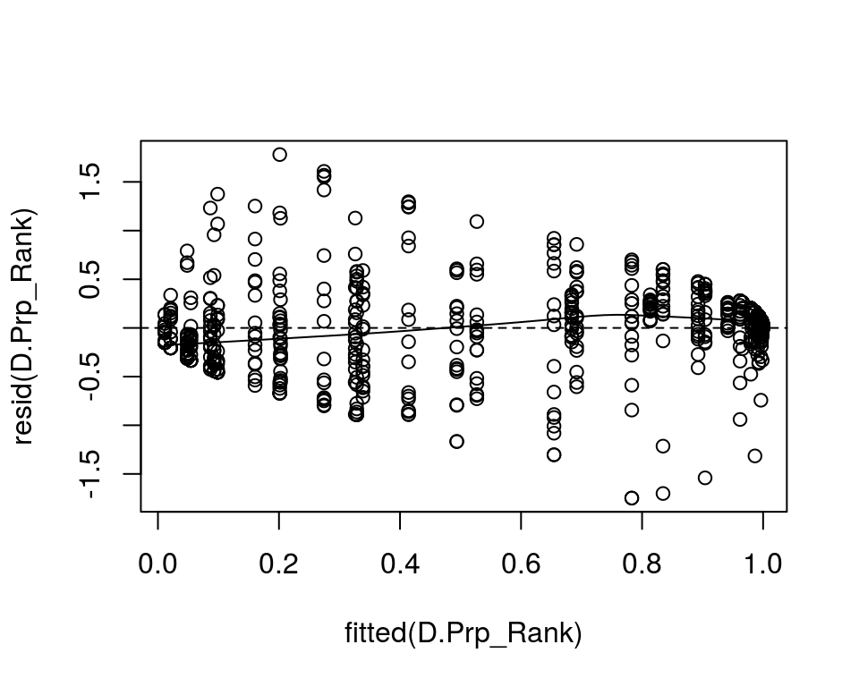

```r
    #drop1(D.Prp_BM, test="F")

  # E.Prp<-effects::Effect(c( "Days", "D.PrpRank_Ini"), D.Prp_Rank, family = quasibinomial,
                # xlevels=list(Days=seq(0, 200, 30)))
  # plot(E.Prp, family = quasibinomial)

  scatter.smooth(fitted(D.Prp_Rank), resid(D.Prp_Rank)); abline(h=0, lty=2)
```

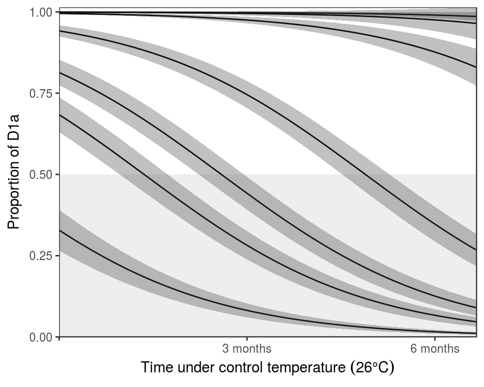

```r
  # Are these residuals ok???

  # Fitted values and plot Change in DProportion ~ days for different Intial D_Proportions
        # create a new data frame
        NewData <- expand.grid(Days=0:200,
                       D.PrpRank_Ini=unique(BeforeBleaching1$D.PrpRank_Ini))
        # get prediction
        pred <- predict(D.Prp_Rank,newdata= NewData,se.fit=TRUE,
                        type = "response")
        # CI function
        make_ci <- function(pred, data){
          # fit, lower, and upper CI
          fit <- pred$fit
          se<-pred$se.fit
          lower <- fit - 1.96*pred$se.fit
          upper <- fit + 1.96*pred$se.fit
          return(data.frame(fit, lower, upper, data))
        }
        my_pred <- make_ci(pred, NewData)

        # my_pred$D_Proportion[my_pred$D.PrpRank_Ini=="[9,109]"]<-"0.0 to 0.612"
        # my_pred$D_Proportion[my_pred$D.PrpRank_Ini=="(109,209]"]<-"0.615 to 0.834"
        # my_pred$D_Proportion[my_pred$D.PrpRank_Ini=="(209,309]"]<-"0.840 to 0.932"
        # my_pred$D_Proportion[my_pred$D.PrpRank_Ini=="(309,409]"]<-"0.934 to 0.991"
        # my_pred$D_Proportion[my_pred$D.PrpRank_Ini=="(409,509]"]<-"0.992 to 0.998"
        # my_pred$D_Proportion[my_pred$D.PrpRank_Ini=="(509,609]"]<-"0.999"
        # my_pred$D_Proportion[my_pred$D.PrpRank_Ini=="(609,709]"]<-"1"
        # my_pred$D_Proportion<-as.factor(my_pred$D_Proportion)


  #tiff('outputs/D_ProportionAt26C.tiff', units="in", width=6, height=4, res=300)

        Dprop <- ggplot(my_pred, aes (Days, fit, shape=D.PrpRank_Ini)) +
          # scale_fill_gradient(low = "blue", high = "green", midpoint = 0.5)+
          # scale_colour_brewer(type = "Diverging", palette = "RdBu", direction = -1) +
          geom_line() + theme_bw( ) +
          geom_ribbon(aes(ymin=my_pred$lower,
                          ymax=my_pred$upper),
                          linetype=0, alpha=0.3) +
          scale_y_continuous(name="Proportion of D1a", expand = c(0, 0)) +
          scale_x_continuous(name=expression("Time under control temperature "(26*degree*C)),
                            breaks = c(0, 90, 180),
                            label = c("", "3 months", "6 months"),
                            expand = c(0, 0)) +
          theme(legend.position="none",
                panel.grid.major = element_blank(), panel.grid.minor = element_blank())
        Dprop +
          annotate("rect", xmin= 0, xmax = 200,
                   ymin = 0, ymax = 0.5, alpha = .1)
```

```r
  #dev.off()

# Colony Model (Not used)

D.Prp_Colony<-glm (D.Prp~ Days * Colony + Tre_1 , family = quasibinomial,
                                  data=BeforeBleaching1,  na.action=na.omit)

      summary(D.Prp_Colony)
```

```
##
## Call:
## glm(formula = D.Prp ~ Days * Colony + Tre_1, family = quasibinomial,
##     data = BeforeBleaching1, na.action = na.omit)
##
## Deviance Residuals:
##      Min        1Q    Median        3Q       Max
## -1.49296  -0.25286   0.02265   0.17495   2.03039
##
## Coefficients:
##                 Estimate Std. Error t value Pr(>|t|)
## (Intercept)    0.8518649  0.4069081   2.094 0.036658 *
## Days          -0.0132183  0.0017563  -7.526 1.59e-13 ***
## ColonyS4       0.7881718  0.2309564   3.413 0.000680 ***
## ColonyS3       1.9205029  0.2525056   7.606 9.00e-14 ***
## ColonyS5       3.9204510  0.4078490   9.613  < 2e-16 ***
## ColonyS6       6.4652962  1.3358518   4.840 1.60e-06 ***
## ColonyS2       8.9723439  3.3211513   2.702 0.007066 **
## Tre_1Control  -1.5787015  0.3918726  -4.029 6.22e-05 ***
## Tre_1Fe       -0.8200387  0.3892964  -2.106 0.035514 *
## Tre_1N        -0.5241821  0.3890101  -1.347 0.178257
## Tre_1N+P      -1.3736989  0.3908972  -3.514 0.000469 ***
## Tre_1N+P+Food -0.4950310  0.3890043  -1.273 0.203591
## Days:ColonyS4 -0.0051123  0.0025168  -2.031 0.042600 *
## Days:ColonyS3 -0.0107888  0.0026065  -4.139 3.90e-05 ***
## Days:ColonyS5 -0.0003586  0.0029927  -0.120 0.904662
## Days:ColonyS6  0.0020723  0.0087134   0.238 0.812086
## Days:ColonyS2 -0.0078052  0.0189695  -0.411 0.680858
## ---
## Signif. codes:  0 '***' 0.001 '**' 0.01 '*' 0.05 '.' 0.1 ' ' 1
##
## (Dispersion parameter for quasibinomial family taken to be 0.2159191)
##
##     Null deviance: 654.49  on 726  degrees of freedom
## Residual deviance: 143.27  on 710  degrees of freedom
## AIC: NA
##
## Number of Fisher Scoring iterations: 10
```

```r
      MASS::dropterm(D.Prp_Colony, test="F")  # Partial F-tests. All the terms are signficant :/
```

```
## Single term deletions
##
## Model:
## D.Prp ~ Days * Colony + Tre_1
##             Df Deviance F value     Pr(F)
## <none>           143.27
## Tre_1        5   157.78 14.3849 1.953e-13 ***
## Days:Colony  5   147.90  4.5949 0.0003923 ***
## ---
## Signif. codes:  0 '***' 0.001 '**' 0.01 '*' 0.05 '.' 0.1 ' ' 1
```

```r
  #     E.Prp<-effects::Effect(c("Days", "Colony"), partial.residuals=F, D.Prp_Colony, family = quasibinomial,
  #                     xlevels=list(Days=seq(0, 200, 30)))
  #     plot(E.Prp, family = "quasibinomial")
  #
  #     scatter.smooth(fitted(D.Prp_Colony), resid(D.Prp_Colony)); abline(h=0, lty=2)
  #     # How quasibinomial residuals are supposed to look?
  #
  #
  #  # Fitted values and plot Change in DProportion ~ days for different Intial D_Proportions
  #       # create a new data frame
  #       ColonyData <- expand.grid(Days=0:200,
  #                      Colony=unique(BeforeBleaching1$Colony),
  #                      Tre_1=unique(BeforeBleaching1$Tre_1))
  #       # get prediction
  #       pred <- predict(D.Prp_Colony,newdata= ColonyData,se.fit=TRUE,
  #                       type = "response")
  #       # CI function
  #       make_ci <- function(pred, data){
  #         # fit, lower, and upper CI
  #         fit <- pred$fit
  #         lower <- fit - 2*pred$se.fit
  #         upper <- fit + 2*pred$se.fit
  #         return(data.frame(fit, lower, upper, data))
  #       }
  #       my_pred <- make_ci(pred, ColonyData)
  #
  # tiff('outputs/D_Pro_Col_At26C.tiff', units="in", width=6, height=4, res=300)
  #
  #       Dprop <- ggplot(my_pred, aes (Days, fit, colour=Tre_1, shape=Tre_1)) +
  #         # scale_fill_gradient(low = "blue", high = "green", midpoint = 0.5)+
  #         # scale_colour_brewer(type = "Diverging", palette = "RdBu", direction = -1) +
  #         geom_line() + theme_bw( ) +
  #         geom_ribbon(aes(ymin=my_pred$lower,
  #                         ymax=my_pred$upper),
  #                         linetype=0, alpha=0.3) +
  #         scale_y_continuous(name="Proportion of D1a", expand = c(0, 0)) +
  #         scale_x_continuous(name=expression("Time under control temperature "(26*degree*C)),
  #                           breaks = c(0, 90, 180),
  #                           label = c("", "3 months", "6 months"),
  #                           expand = c(0, 0)) +
  #         theme(legend.position="none",
  #               panel.grid.major = element_blank(), panel.grid.minor = element_blank())
  #       Dprop +
  #         annotate("rect", xmin= 0, xmax = 200,
  #                  ymin = 0, ymax = 0.5, alpha = .1)
  # dev.off()

anova(D.Prp_Rank, D.Prp_Colony, test = "F")
```

```
## Analysis of Deviance Table
##
## Model 1: D.Prp ~ Days + D.PrpRank_Ini
## Model 2: D.Prp ~ Days * Colony + Tre_1
##   Resid. Df Resid. Dev Df Deviance F Pr(>F)
## 1       719     126.64
## 2       710     143.27  9  -16.622
```

### 2. Model for the corals that where not bleached the first time (2016)

Cores that were not bleached in 2016 were moved to in ambient temperature tanks (Temperature and light variable). The transition to C dominance seems to be slower than under constant 26C, but these are a good experiment of long term evolution of the D proportions at “field” temperatures when there is not bleaching conditions.

- Used this data to describe the changes in D proportion under ambient ~26-29C (Bleached==“No”).
- Data until before second bleaching event (Days<690)

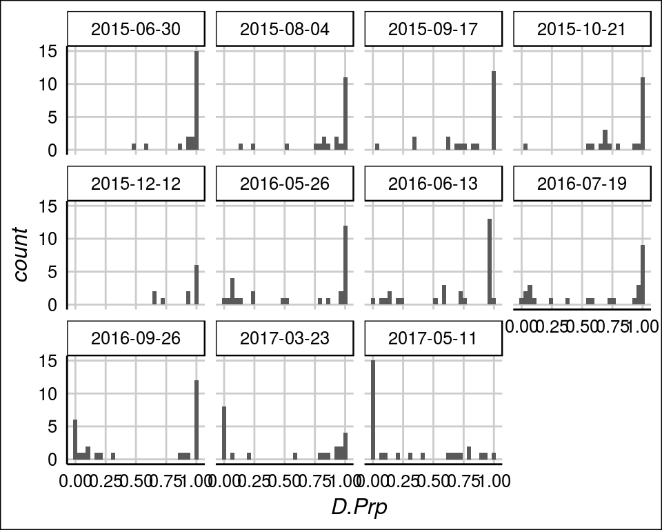

```r
NotBleached<-subset(qPCR.data, Days<690) # Remove data points after second bleaching
NotBleached<-subset(NotBleached, Bleached_1=="No")

# Add Initial D proportion in each core during the earliest time with available data
# (T= min)

for (Core in NotBleached$Core) {
  tdata <- NotBleached[which(NotBleached$Core==Core), ]
  for (Days in NotBleached$Days) {
    tdata[which(tdata$Days==Days), "Initial_D"] <- tdata[which.min(tdata$Days), "D.Prp"]
  }
  NotBleached[which(NotBleached$Core==Core), "Initial_D"] <- tdata[, "Initial_D"]
}

# D proporion histograms
  Dprop_Hist <- ggplot(NotBleached, aes (D.Prp)) +
    geom_histogram() + facet_wrap(~Date) +  theme_gdocs( )
  Dprop_Hist
```

```r
# Note: Almost no data points <50% D at time T=T0 (2015-06-30)
```

Rank the cores by Initial D proportion.

There is even fewer C dominated cores at the begining of the experiment in these subset od the data

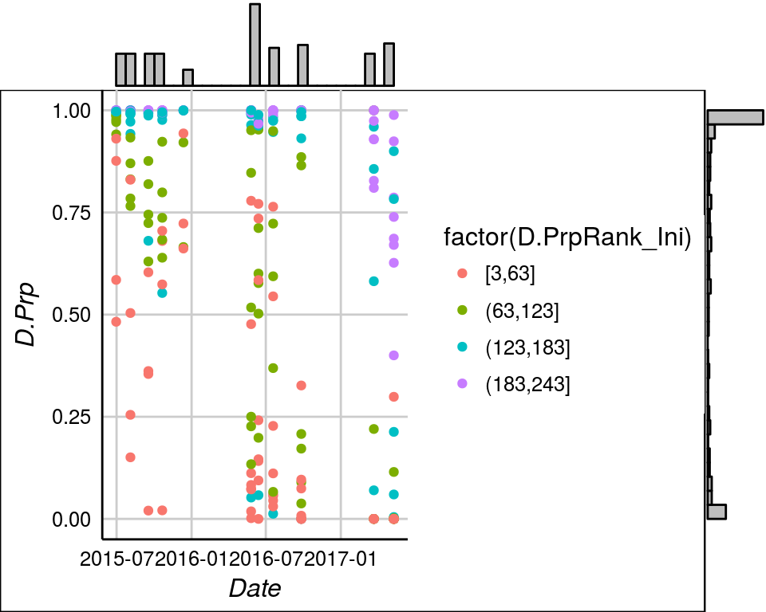

```r
# Initial D_segments

NotBleached$D.PrpRank_Ini<-rank(NotBleached$Initial_D)
NotBleached$D.PrpRank_Ini<-cut(NotBleached$D.PrpRank_Ini,
                                      seq(3,243,60), include.lowest=TRUE)

Dprop_NoBleaching <- ggplot(NotBleached, aes (Date, D.Prp, colour=factor(D.PrpRank_Ini))) +
    geom_point(width = 0.5) +  theme_gdocs( )
ggExtra::ggMarginal(Dprop_NoBleaching, type = 'histogram', margins = 'both',
                    size = 5,  colour = 'black',  fill = 'gray')
```

Define and test the model

```r
# Initial Proportion Model by rank

  D.Prp_Rank_2<-glm (D.Prp ~ Days + D.PrpRank_Ini, family = quasibinomial,
                 data=NotBleached,  na.action=na.omit)

    summary(D.Prp_Rank_2)
```

```
##
## Call:
## glm(formula = D.Prp ~ Days + D.PrpRank_Ini, family = quasibinomial,
##     data = NotBleached, na.action = na.omit)
##
## Deviance Residuals:
##     Min       1Q   Median       3Q      Max
## -1.7914  -0.3001   0.0925   0.2866   1.9122
##
## Coefficients:
##                          Estimate Std. Error t value Pr(>|t|)
## (Intercept)             0.7667492  0.2251284   3.406 0.000766 ***
## Days                   -0.0060801  0.0005556 -10.943  < 2e-16 ***
## D.PrpRank_Ini(63,123]   1.4228382  0.2558729   5.561 6.77e-08 ***
## D.PrpRank_Ini(123,183]  2.9844552  0.2923613  10.208  < 2e-16 ***
## D.PrpRank_Ini(183,243]  5.1657579  0.4157870  12.424  < 2e-16 ***
## ---
## Signif. codes:  0 '***' 0.001 '**' 0.01 '*' 0.05 '.' 0.1 ' ' 1
##
## (Dispersion parameter for quasibinomial family taken to be 0.3056535)
##
##     Null deviance: 219.337  on 259  degrees of freedom
## Residual deviance:  73.636  on 255  degrees of freedom
## AIC: NA
##
## Number of Fisher Scoring iterations: 6
```

```r
    MASS::dropterm(D.Prp_Rank_2, test="F")  # Partial F-tests
```

```
## Single term deletions
##
## Model:
## D.Prp ~ Days + D.PrpRank_Ini
##               Df Deviance F value     Pr(F)
## <none>             73.636
## Days           1  124.831  177.29 < 2.2e-16 ***
## D.PrpRank_Ini  3  179.108  121.75 < 2.2e-16 ***
## ---
## Signif. codes:  0 '***' 0.001 '**' 0.01 '*' 0.05 '.' 0.1 ' ' 1
```

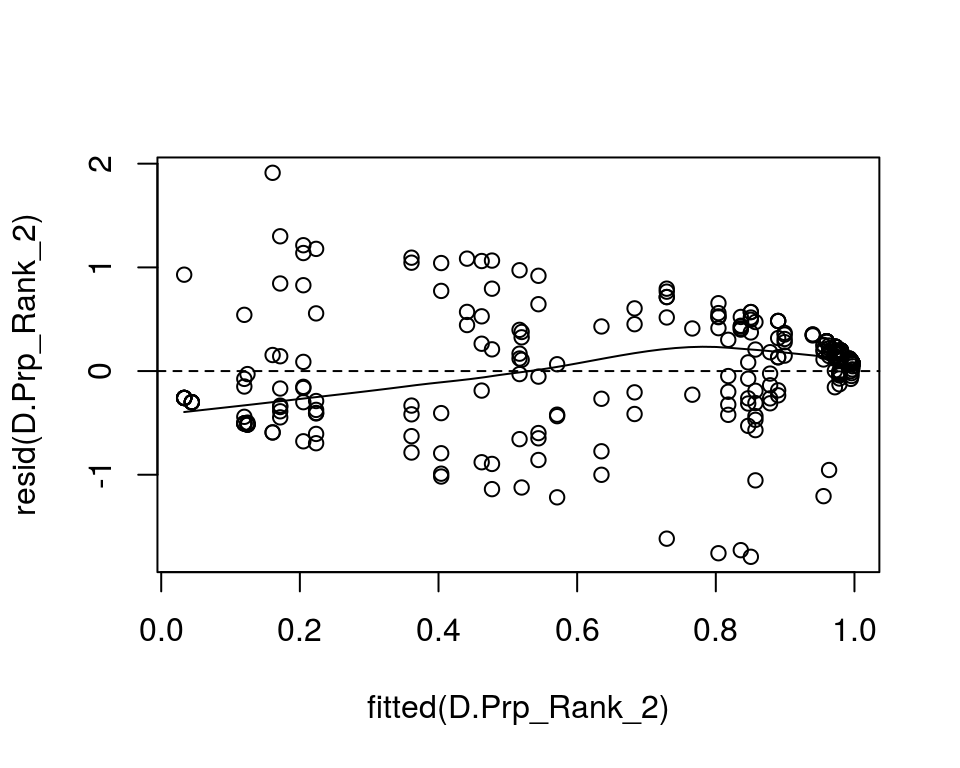

```r
    E.Prp<-effects::Effect(c( "Days", "D.PrpRank_Ini"), D.Prp_Rank_2, family = quasibinomial,
                xlevels=list(Days=seq(0, 200, 30)))
  #plot(E.Prp, family = quasibinomial)

  scatter.smooth(fitted(D.Prp_Rank_2), resid(D.Prp_Rank_2)); abline(h=0, lty=2)
```

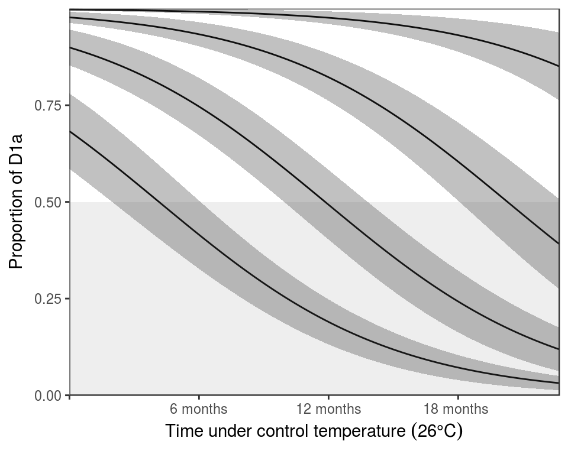

```r
    # Fitted values and plot Change in D Proportion ~ days for different Intial D_Proportions

  # create a new data frame
        NotBleachedData <- expand.grid(Days=0:690,
                       D.PrpRank_Ini=unique(NotBleached$D.PrpRank_Ini))
        # get prediction
        pred <- predict(D.Prp_Rank_2,newdata= NotBleachedData, se.fit=TRUE,
                        type = "response")
        # CI function
        make_ci <- function(pred, data){
          # fit, lower, and upper CI
          fit <- pred$fit
          lower <- fit - 2*pred$se.fit
          upper <- fit + 2*pred$se.fit
          return(data.frame(fit, lower, upper, data))
        }
        my_pred <- make_ci(pred, NotBleachedData)

#tiff('outputs/D_ProportionAtVariableT.tiff', units="in", width=6, height=4, res=300)

        Dprop <- ggplot(my_pred, aes (Days, fit, shape=D.PrpRank_Ini)) +
          # scale_fill_gradient(low = "blue", high = "green", midpoint = 0.5)+
          # scale_colour_brewer(type = "Diverging", palette = "RdBu", direction = -1) +
          geom_line() + theme_bw( ) +
          geom_ribbon(aes(ymin=my_pred$lower,
                          ymax=my_pred$upper),
                          linetype=0, alpha=0.3) +
          scale_y_continuous(name="Proportion of D1a", expand = c(0, 0)) +
          scale_x_continuous(name=expression("Time under control temperature "(26*degree*C)),
                            breaks = c(0, 182.5, 365, 547.5),
                            label = c("", "6 months", "12 months", "18 months "),
                            expand = c(0, 0)) +
          theme(legend.position="none",
                panel.grid.major = element_blank(), panel.grid.minor = element_blank())
        Dprop +
          annotate("rect", xmin= 0, xmax = 690,
                   ymin = 0, ymax = 0.5, alpha = .1)
```

```r
 # dev.off()
```